# Chapter 6

The analysis and results of week 6 are presented below. I only did the first exercise and I hope that I have done what I was supposed to do. I would have preferred a clear exercise statement that directly tells what we are asked to do instead of just repeating some random codes with different data sets. But anyway, here we go…

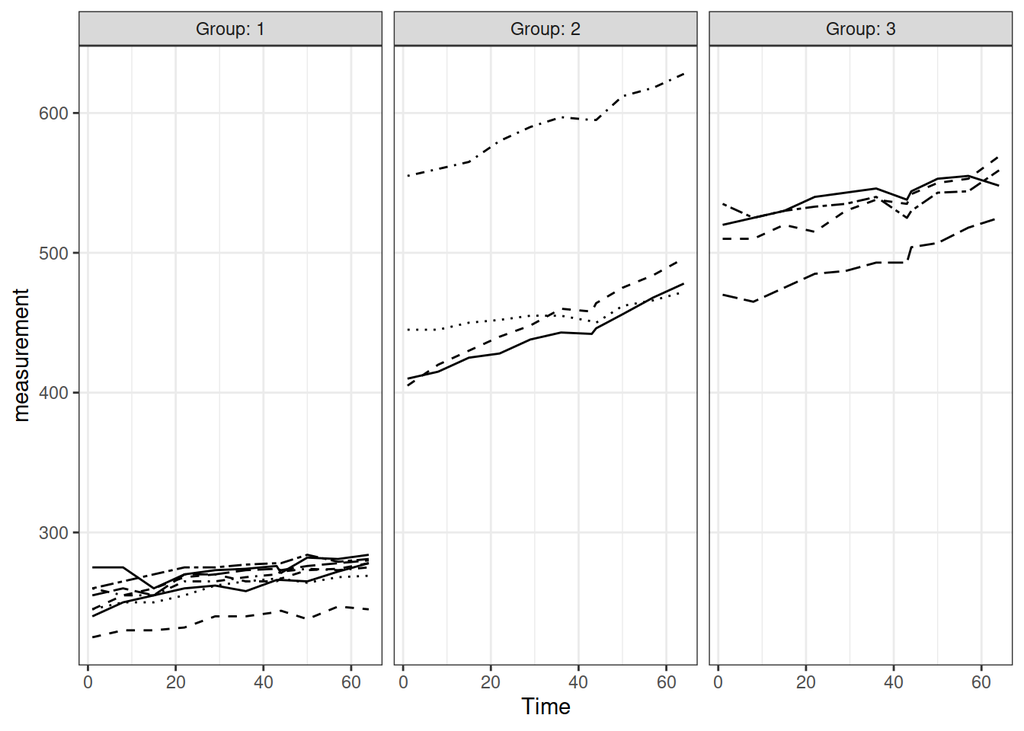

```r
# read and plot rat data
library(readr)
library(tidyverse)
library(ggplot2)

rats = read_csv('data/rats.csv')
rats$ID = factor(rats$ID)
rats$Group = factor(rats$Group)

for(d in c(1,8,15,22,29,36,43,44,50,57,64)){
  rats$Time[rats$Time== paste0('WD', d)] = d
}
rats$Time = as.numeric(rats$Time)

p1 <- ggplot(rats, aes(x = Time, y = measurement, linetype = ID))
p2 <- p1 + geom_line() + scale_linetype_manual(values = rep(1:8, times=4))
p3 <- p2 + facet_grid(. ~ Group, labeller = label_both)
p4 <- p3 + theme_bw() + theme(legend.position = "none")
p5 <- p4 + theme(panel.grid.minor.y = element_blank())
p6 <- p5 + scale_y_continuous(limits = c(min(rats$measurement), max(rats$measurement)))
print(p6)
```

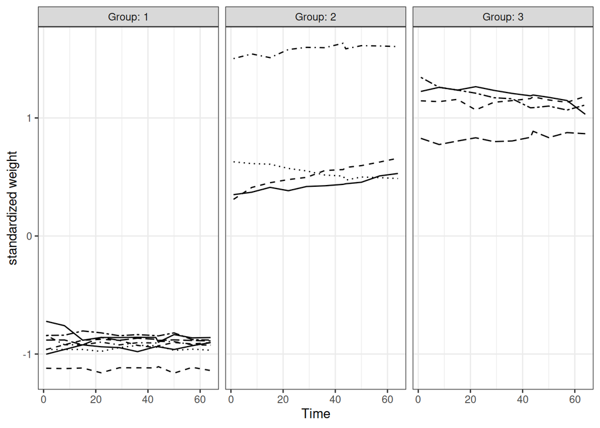

```r
# Standardise the scores:
rats <- rats %>%
  group_by(Time) %>%
  mutate( std_weight = (measurement - mean(measurement))/sd(measurement) ) %>%
  ungroup()

p1 <- ggplot(rats, aes(x = Time, y = std_weight, linetype = ID))
p2 <- p1 + geom_line() + scale_linetype_manual(values = rep(1:8, times=4))
p3 <- p2 + facet_grid(. ~ Group, labeller = label_both)
p4 <- p3 + theme_bw() + theme(legend.position = "none")
p5 <- p4 + theme(panel.grid.minor.y = element_blank())
p6 <- p5 + scale_y_continuous(name = "standardized weight")
print(p6)
```

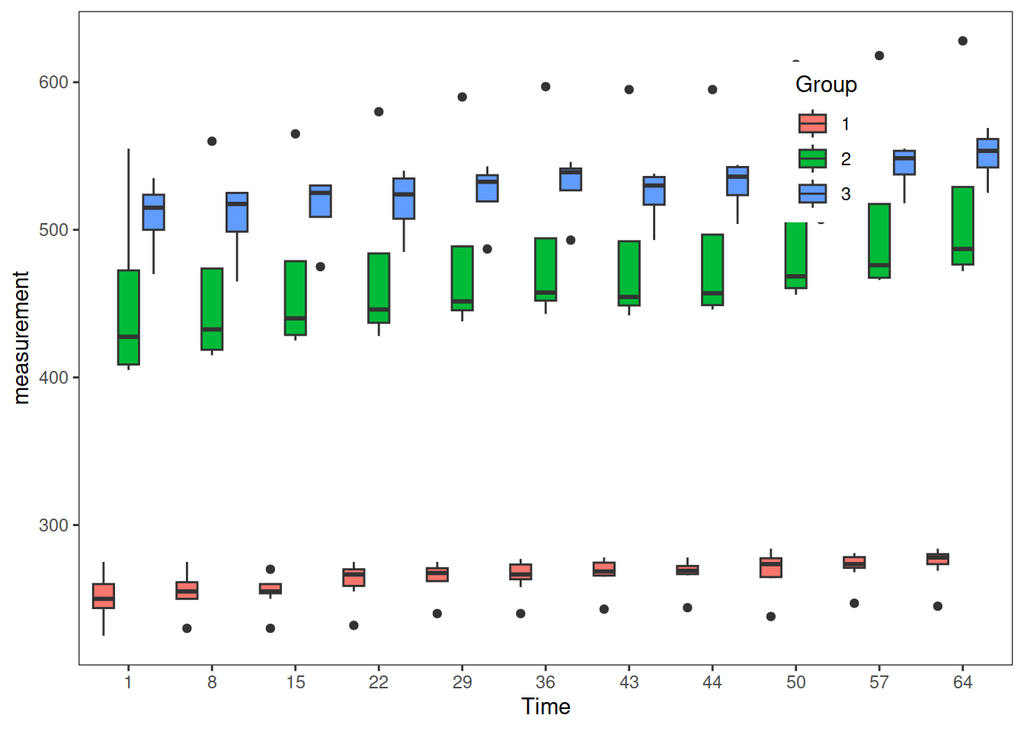

```r
p1 <- ggplot(rats, aes(x = factor(Time), y = measurement, fill = Group))
p2 <- p1 + geom_boxplot(position = position_dodge(width = 0.9))
p3 <- p2 + theme_bw() + theme(panel.grid.major = element_blank(), panel.grid.minor = element_blank())
p4 <- p3 + theme(legend.position = c(0.8,0.8))
p5 <- p4 + scale_x_discrete(name = "Time")
p5
```

All figures show that the rats in different treatment groups differ a lot from each other. Especially rats in group 1 were much smaller than other rats to begin with. All rats seem to have gained weight during the study.

```r
rats2 <- rats %>%
  filter(Time > 1) %>%
  group_by(Group, ID) %>%
  summarise( mean=mean(measurement) ) %>%
  ungroup()
```

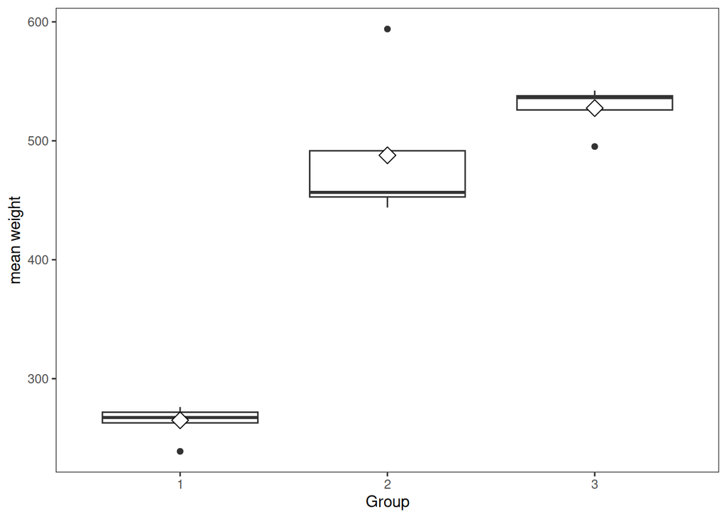

```r
p1 <- ggplot(rats2, aes(x = Group, y = mean))
p2 <- p1 + geom_boxplot()
p3 <- p2 + theme_bw() + theme(panel.grid.major = element_blank(), panel.grid.minor = element_blank())
p4 <- p3 + stat_summary(fun.y = "mean", geom = "point", shape=23, size=4, fill = "white")
p5 <- p4 + scale_y_continuous(name = "mean weight")
p5
```

In the textbook example some outliers were excluded at this point of analysis but I don’t think that this data set contains too weird outliers so we continue with the original data set.

```r
rats2a = rats2[rats2$Group!='1',]
t.test(mean ~ Group, data = rats2a, var.equal = TRUE)
```

```
##
##  Two Sample t-test
##
## data:  mean by Group
## t = -1.0686, df = 6, p-value = 0.3263
## alternative hypothesis: true difference in means between group 2 and group 3 is not equal to 0
## 95 percent confidence interval:
##  -130.60428   51.20428
## sample estimates:
## mean in group 2 mean in group 3
##           487.8           527.5
```

```r
rats2b = rats2[rats2$Group!='2',]
t.test(mean ~ Group, data = rats2b, var.equal = TRUE)
```

```
##
##  Two Sample t-test
##
## data:  mean by Group
## t = -27.824, df = 10, p-value = 8.345e-11
## alternative hypothesis: true difference in means between group 1 and group 3 is not equal to 0
## 95 percent confidence interval:
##  -283.4943 -241.4557
## sample estimates:
## mean in group 1 mean in group 3
##         265.025         527.500
```

```r
rats2c = rats2[rats2$Group!='3',]
t.test(mean ~ Group, data = rats2c, var.equal = TRUE)
```

```
##
##  Two Sample t-test
##
## data:  mean by Group
## t = -9.0646, df = 10, p-value = 3.88e-06
## alternative hypothesis: true difference in means between group 1 and group 2 is not equal to 0
## 95 percent confidence interval:
##  -277.5345 -168.0155
## sample estimates:
## mean in group 1 mean in group 2
##         265.025         487.800
```

As above plots and t-tests demonstrate, the rats in groups 2 and 3 were significantly bigger than rats in group 1. The differences between groups 2 and 3 are not statistically significant. However, the rats in those groups have been bigger already from the start, so I don’t think that this is a very meaningful or interesting result.

```r
# Add the baseline from the original data as a new variable to the summary data:

baseline <- rats$measurement[rats$Time==1]
rats3 <- rats2 %>%
  mutate(baseline)

# Fit the ANCOVA model and see the results:

fit <- lm(mean ~ baseline + Group, data = rats3)

summary(fit)
```

```
##
## Call:
## lm(formula = mean ~ baseline + Group, data = rats3)
##
## Residuals:
##     Min      1Q  Median      3Q     Max
## -23.905  -4.194   2.190   7.577  14.800
##
## Coefficients:
##             Estimate Std. Error t value Pr(>|t|)
## (Intercept) 33.16375   21.87657   1.516   0.1554
## baseline     0.92513    0.08572  10.793 1.56e-07 ***
## Group2      34.85753   18.82308   1.852   0.0888 .
## Group3      23.67526   23.25324   1.018   0.3287
## ---
## Signif. codes:  0 '***' 0.001 '**' 0.01 '*' 0.05 '.' 0.1 ' ' 1
##
## Residual standard error: 11.68 on 12 degrees of freedom
## Multiple R-squared:  0.9936, Adjusted R-squared:  0.992
## F-statistic: 622.1 on 3 and 12 DF,  p-value: 1.989e-13
```

```r
anova(fit)
```

```
## Analysis of Variance Table
##
## Response: mean
##           Df Sum Sq Mean Sq   F value   Pr(>F)
## baseline   1 253625  253625 1859.8201 1.57e-14 ***
## Group      2    879     439    3.2219  0.07586 .
## Residuals 12   1636     136
## ---
## Signif. codes:  0 '***' 0.001 '**' 0.01 '*' 0.05 '.' 0.1 ' ' 1
```

When we take the initial weight of the rats into account the diet is no longer a statistically significant explanatory variable for the weight of the rats. The differences in weights are mostly due to a large size difference already before the study.

I only did the first exercise.